# Exposition

```
[1] "C:/Users/Rebecca/Documents/GitHub/cognition-stress-activity"
```

## Define Variables

- phys_bl_bp = each persons baseline score - the baseline grand mean (between person baseline compare)
- phys_bp_mean = the persons mean score across occasions - the grand mean
- phys_bp_median = the persons median score across occasions - the grand median
- phys_wp = that persons score at time j, minus their mean (deviations-from–own-mean)
- mmse_wp = the persons mmse score at time j, minus their mean, so that a positive value indicated scores higehr then their mean
- biomarker_high = indicates if the person’s mean on that particular biomarker is above the 3rd quartile

physical activity question: hours per week that the ppt. engages in 5 different categories

## Tweak Data

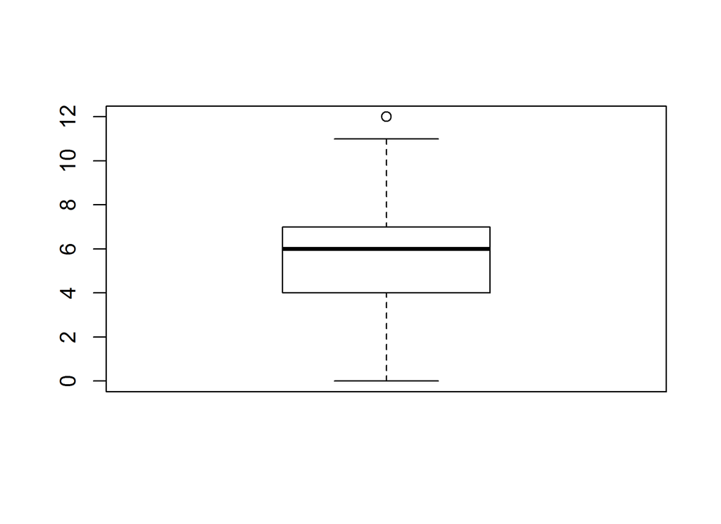

```r
## dsb
boxplot(dtest$dsb)
```

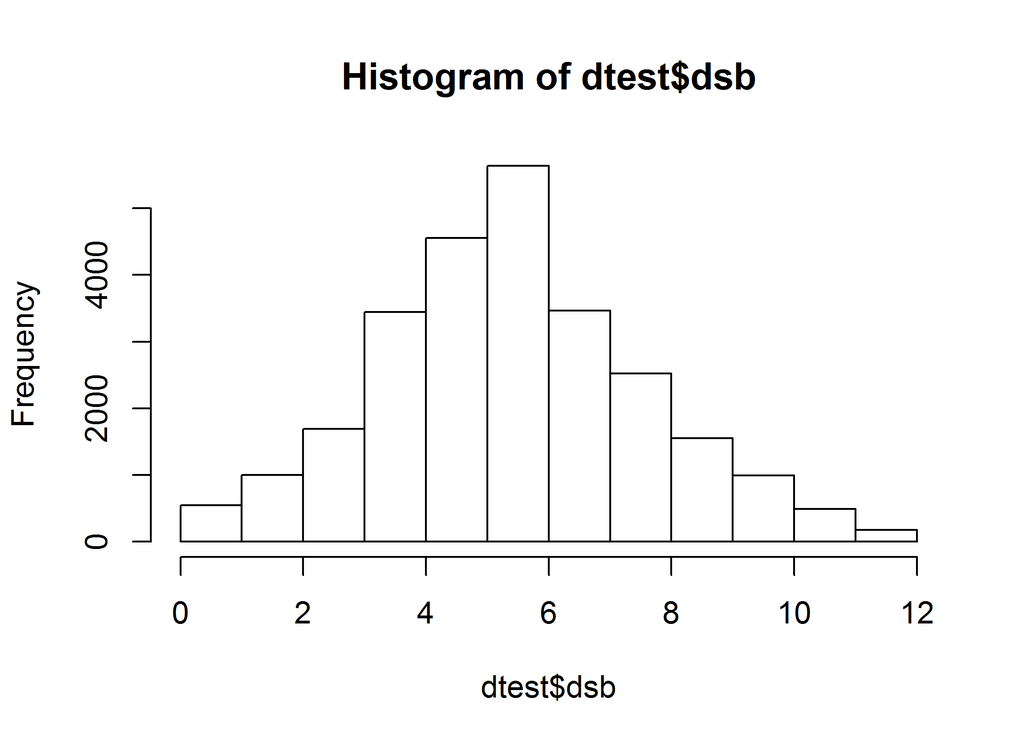

```r
hist(dtest$dsb)
```

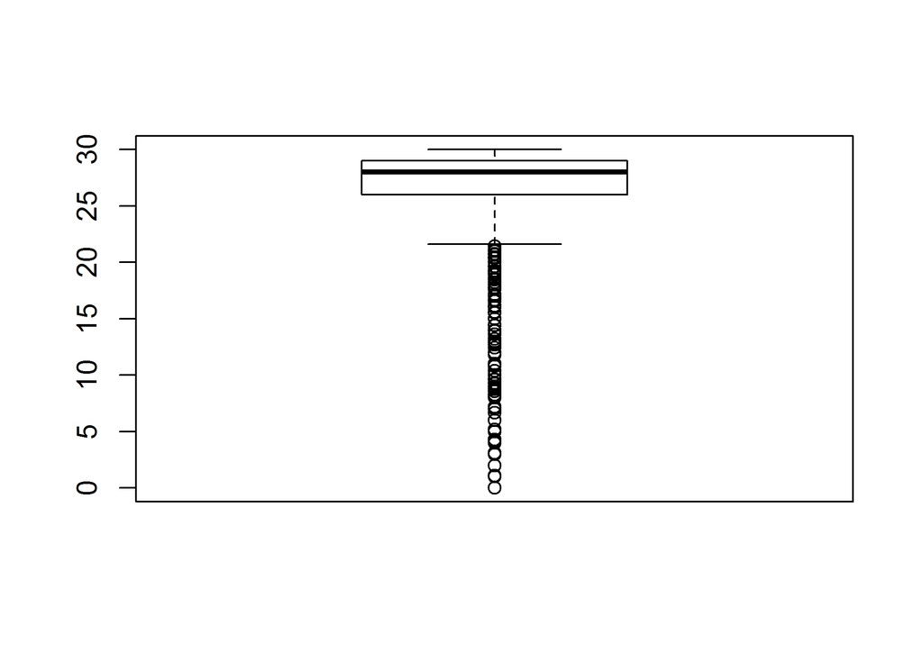

```r
#normally distributed!

## mmse
boxplot(dtest$mmse)
```

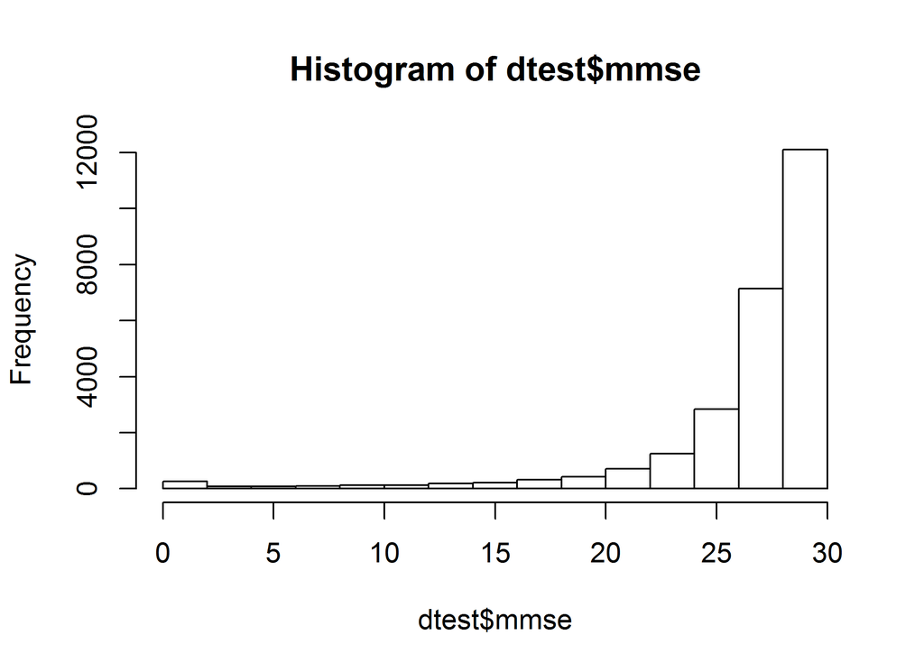

```r
hist(dtest$mmse)
```

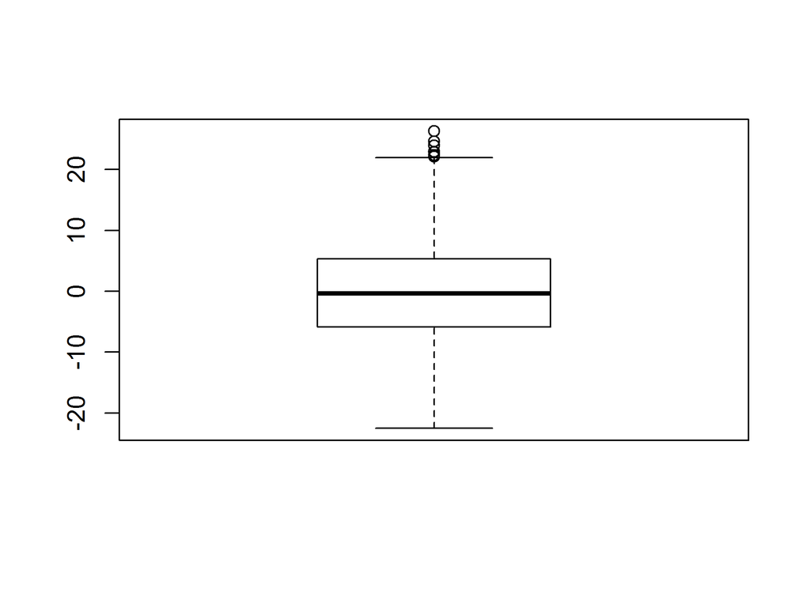

```r
## age
boxplot(dtest$age_bl_centered)
```

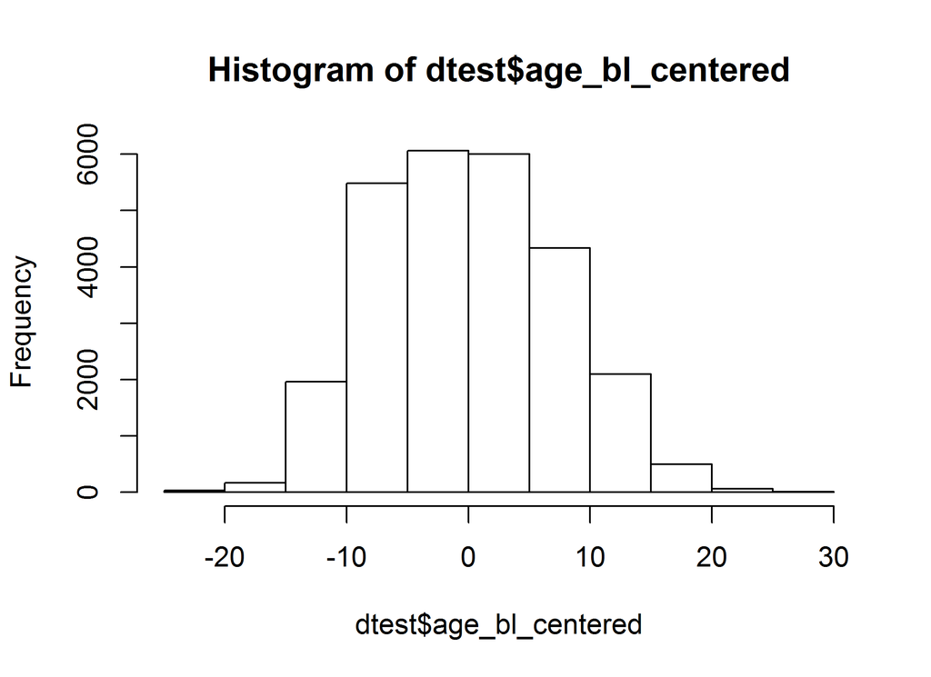

```r
# bp<-boxplot(dtest$age_bl_centered)
# bp$out
hist(dtest$age_bl_centered)
```

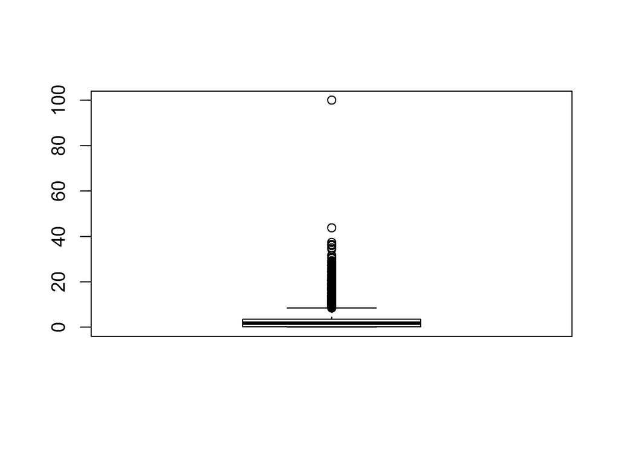

```r
#looks ok

## physical activity raw
boxplot(dtest$physical_activity)
```

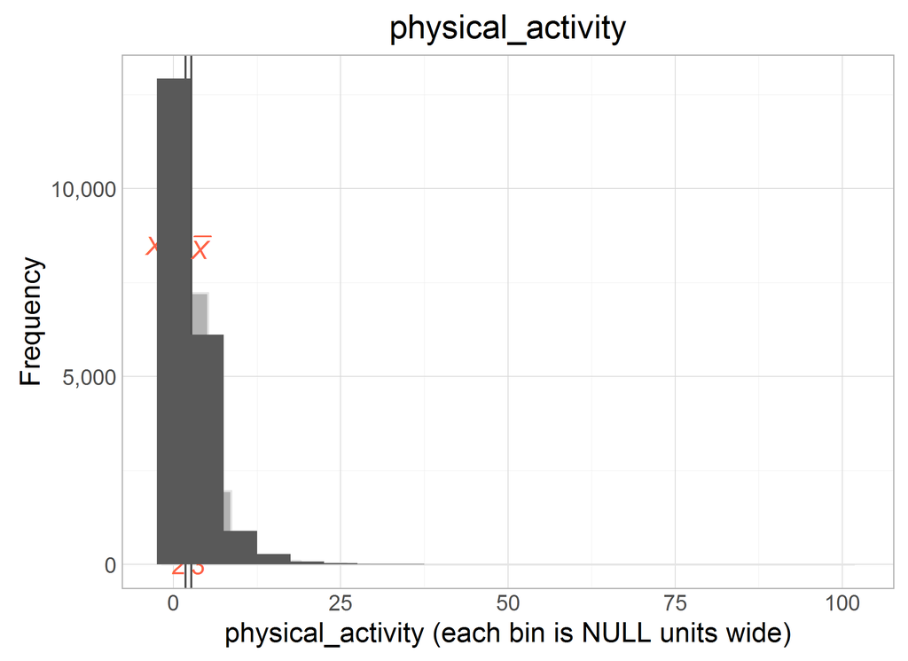

```r
# bp<-boxplot(dtest$physical_activity)
# bp$out
dtest %>% histogram_continuous(variable_name= "physical_activity") + stat_bin(binwidth = 5)
```

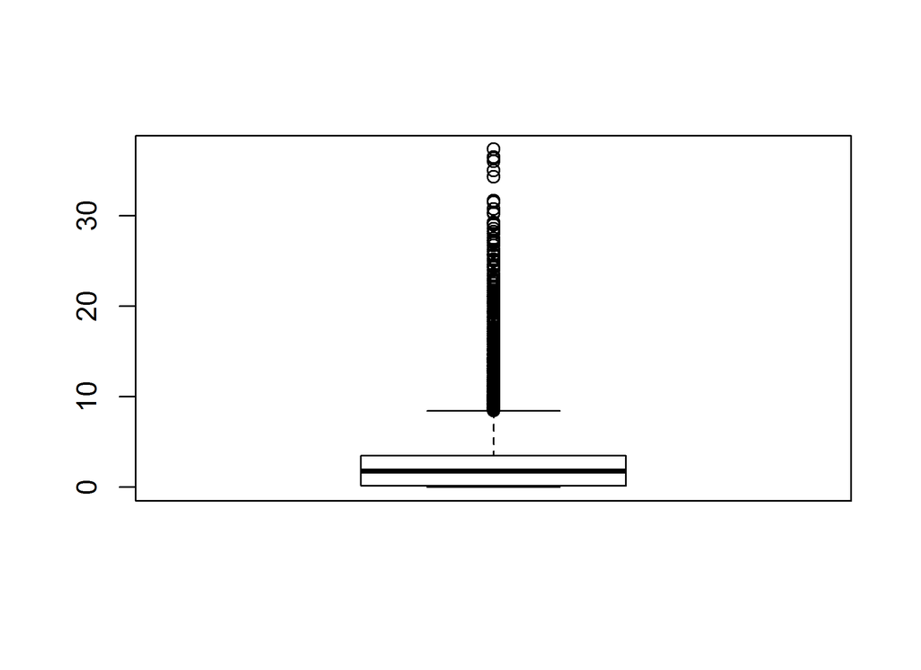

```r
#anything greater than 40 may be an outlier
dtest<- subset(dtest, physical_activity < 40)
boxplot(dtest$physical_activity)
```

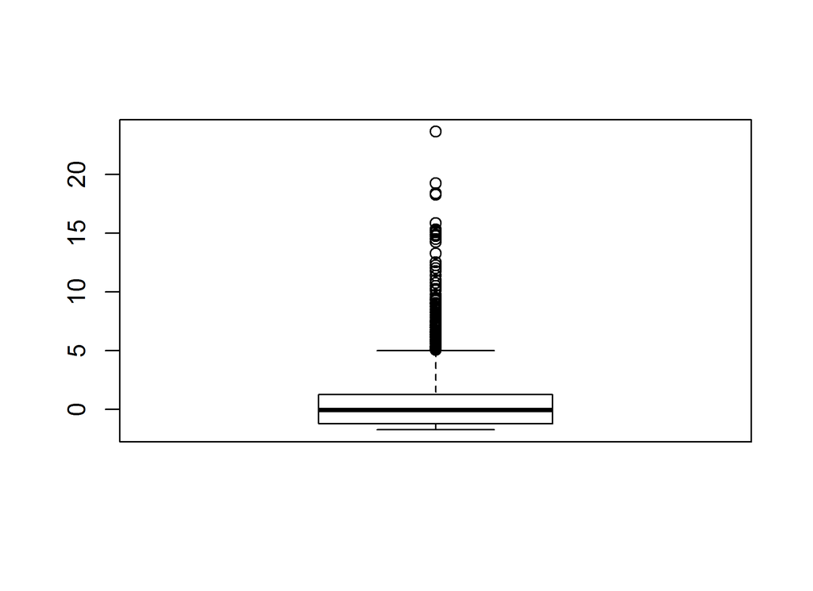

```r
## physical activity bp
boxplot(dtest$phys_bp_median)
```

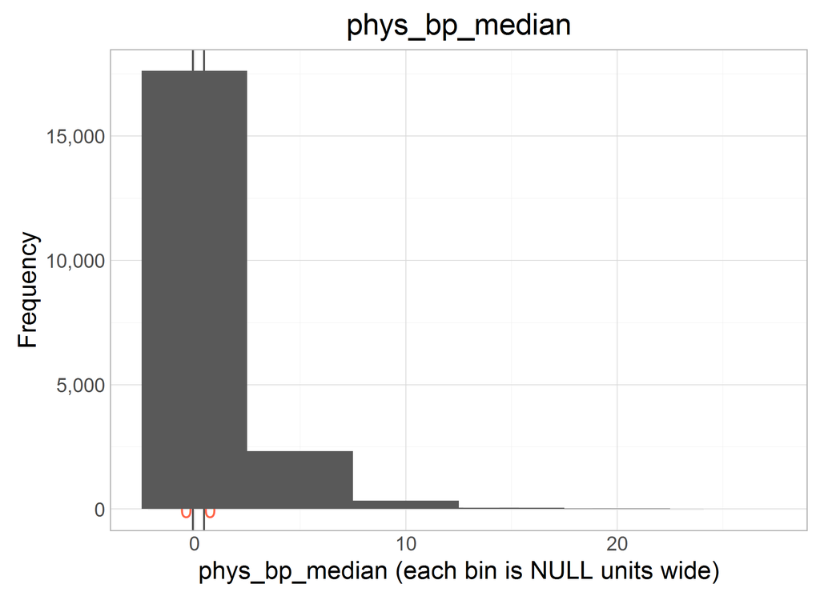

```r
dtest %>% histogram_continuous(variable_name= "phys_bp_median") + stat_bin(binwidth = 5)
```

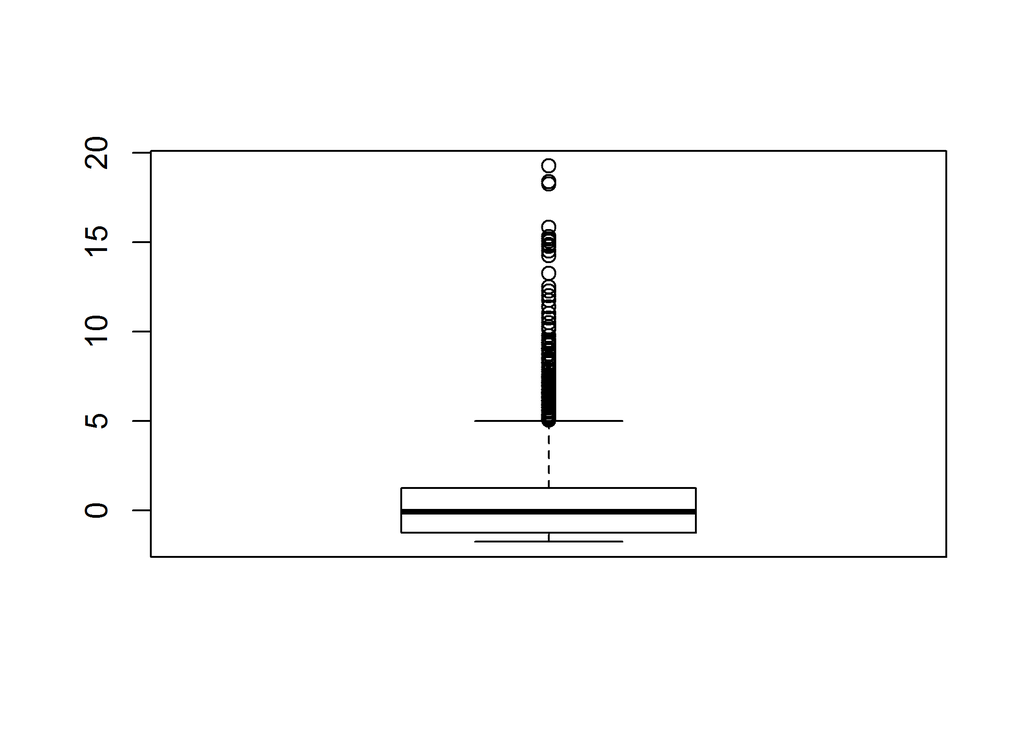

```r
#anything greater than 20 may be an outlier
dtest<- subset(dtest, phys_bp_median < 20)
boxplot(dtest$phys_bp_median)
```

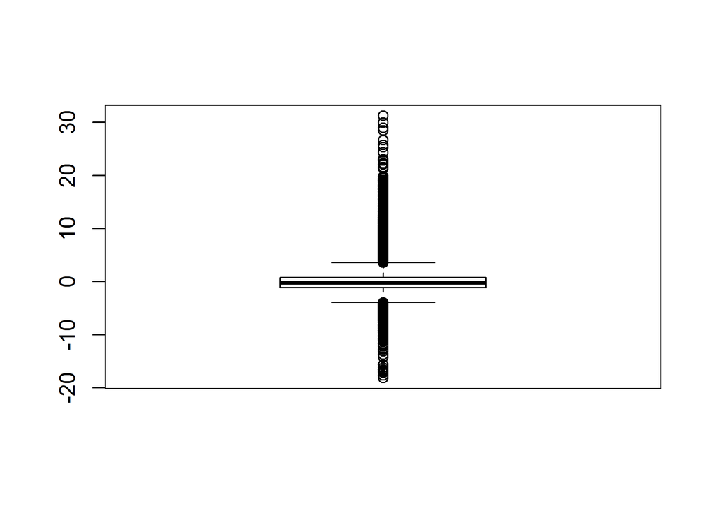

```r
## physical activity wp
boxplot(dtest$phys_wp)
```

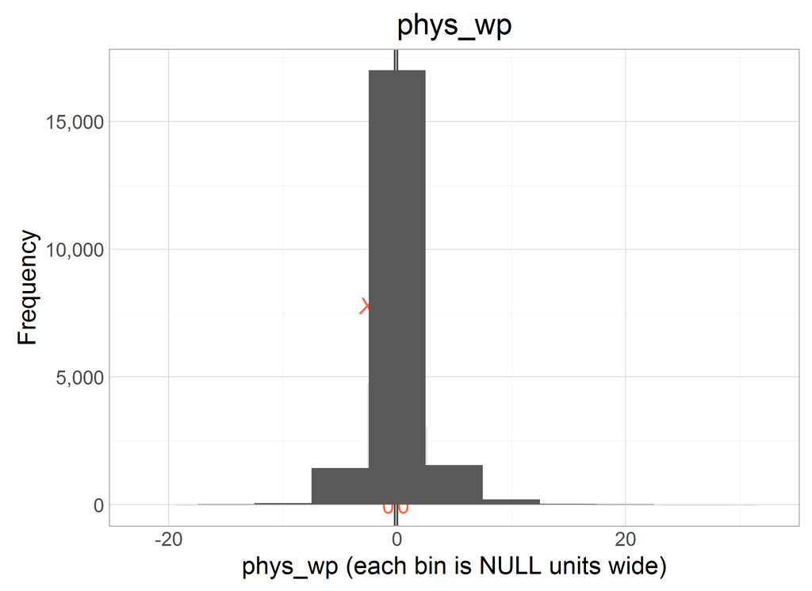

```r
dtest %>% histogram_continuous(variable_name= "phys_wp") + stat_bin(binwidth = 5)
```

```r
#looks good
```

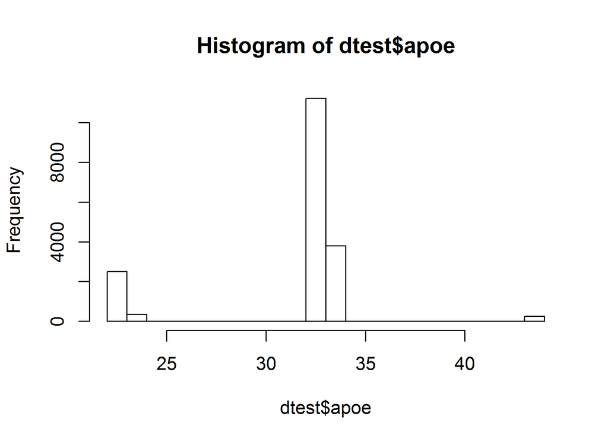

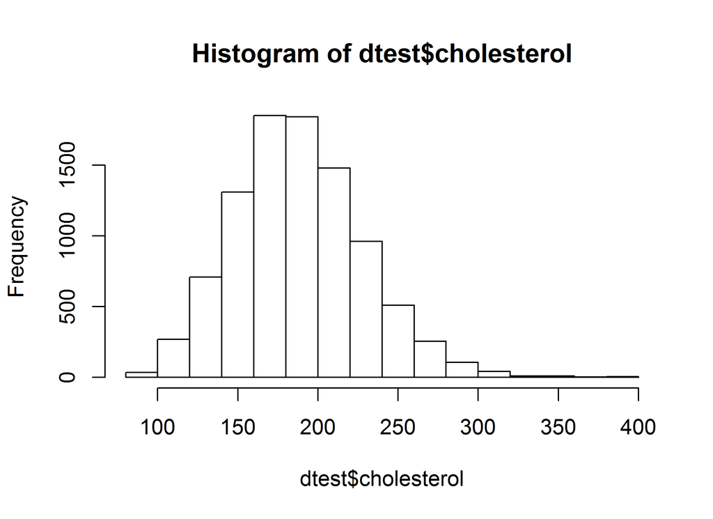

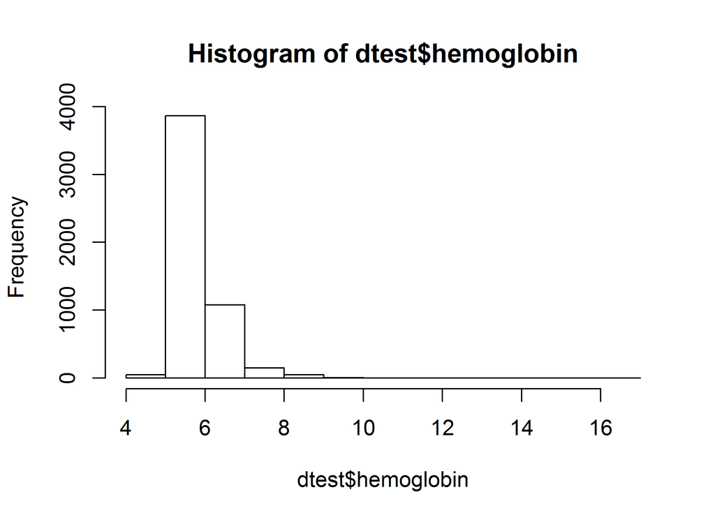

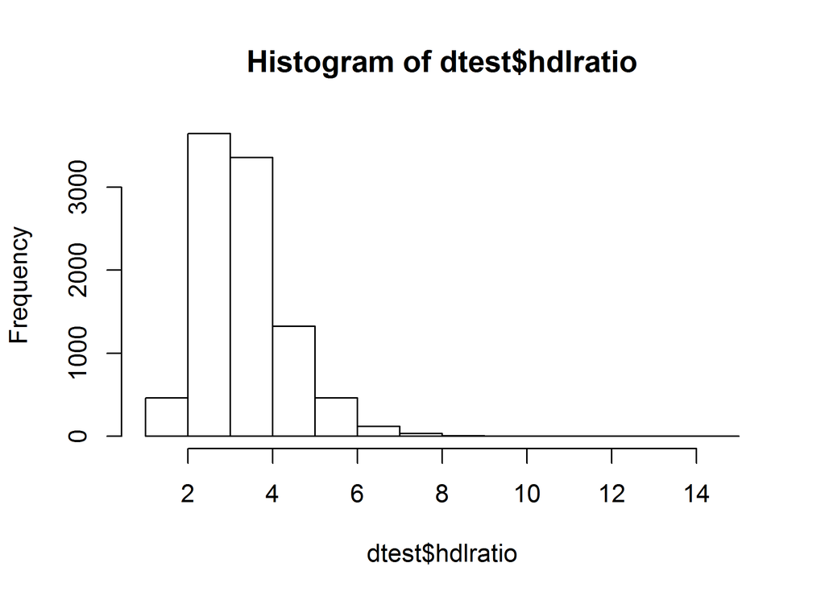

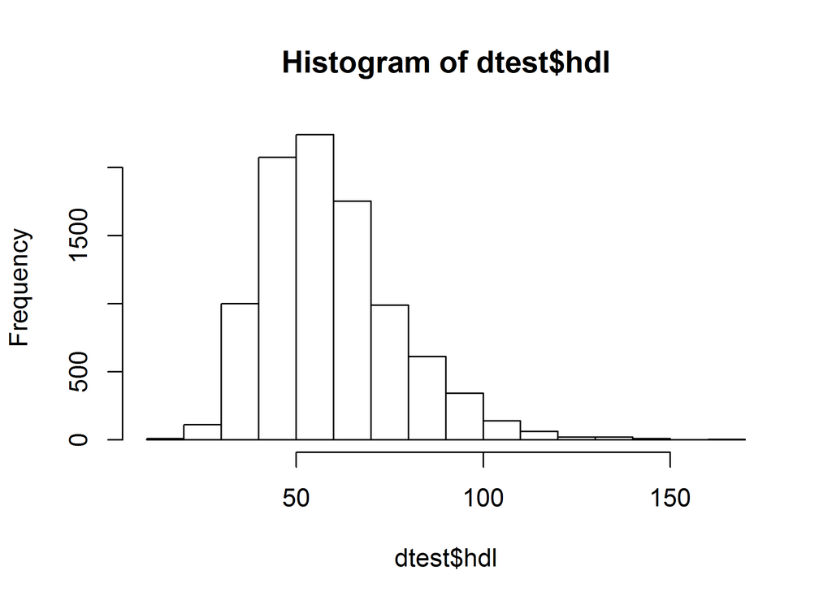

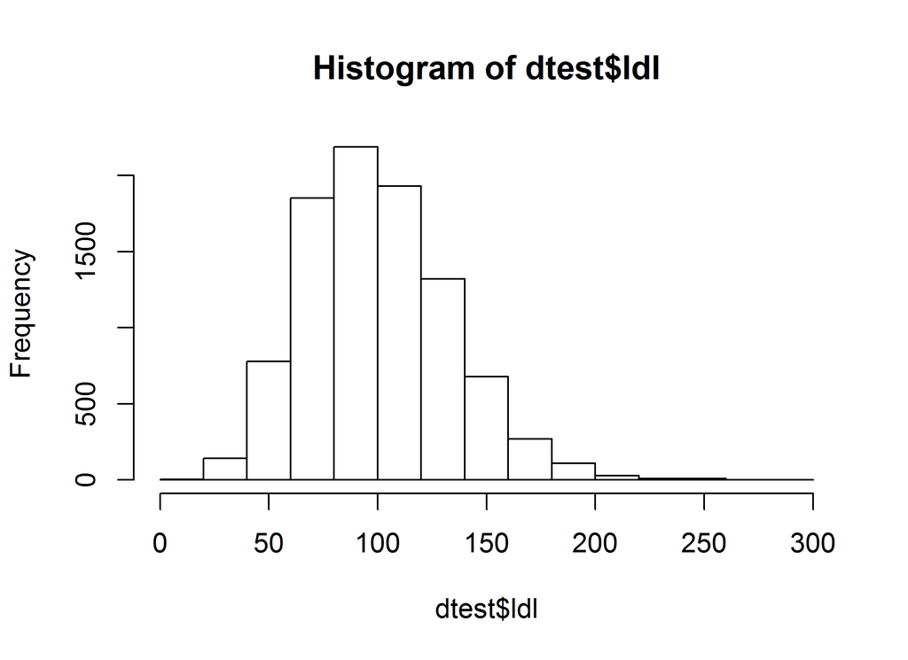

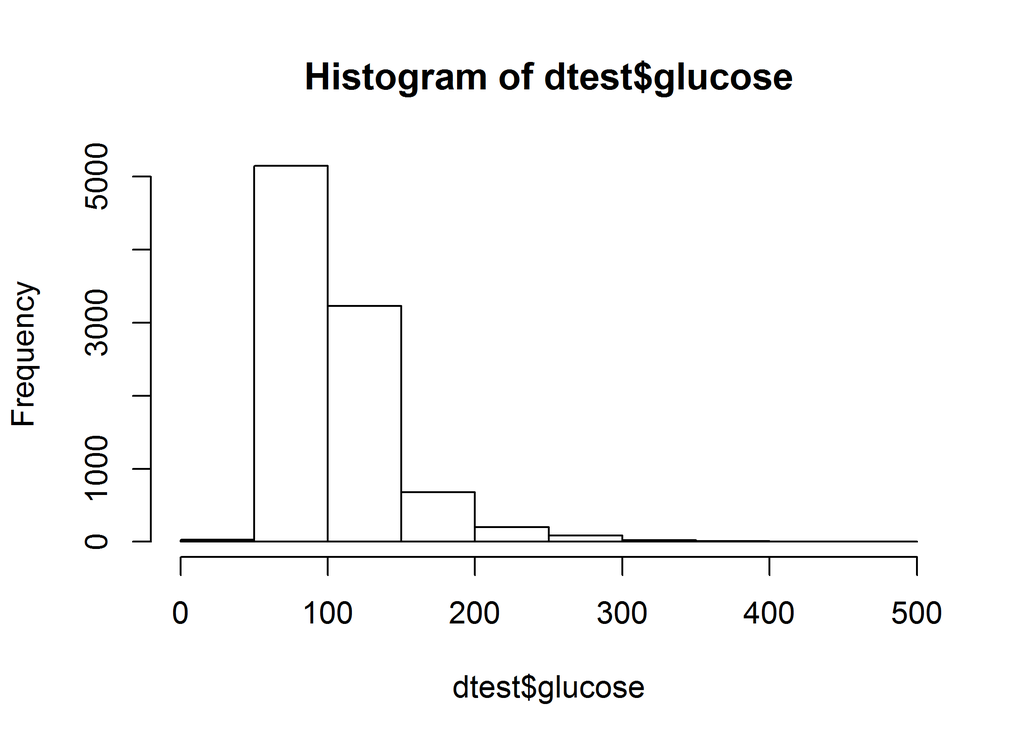

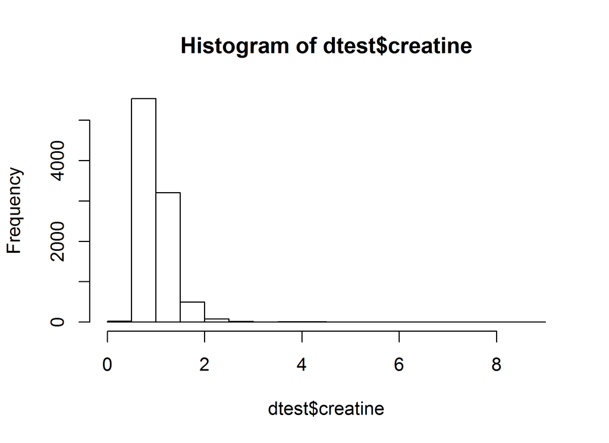

```
  cholesterol_HIGH_wave  freq
1                 FALSE  7202
2                  TRUE  2196
3                    NA 10959
```

```
  hemoglobin_HIGH_wave  freq
1                FALSE  4412
2                 TRUE   796
3                   NA 15149
```

```
  hdl_LOW_wave  freq
1        FALSE  6897
2         TRUE  2501
3           NA 10959
```

```
  ldl_HIGH_wave  freq
1         FALSE  7132
2          TRUE  2187
3            NA 11038
```

```
  glucose_HIGH_wave  freq
1             FALSE  7057
2              TRUE  2335
3                NA 10965
```

```
  creatine_HIGH_wave  freq
1              FALSE  7606
2               TRUE  1786
3                 NA 10965
```

```
  hdlratio_HIGH_wave  freq
1              FALSE  6968
2               TRUE  2430
3                 NA 10959
```

## DSB over time

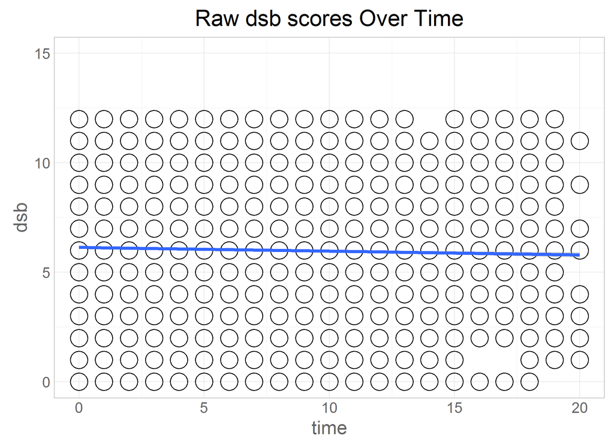

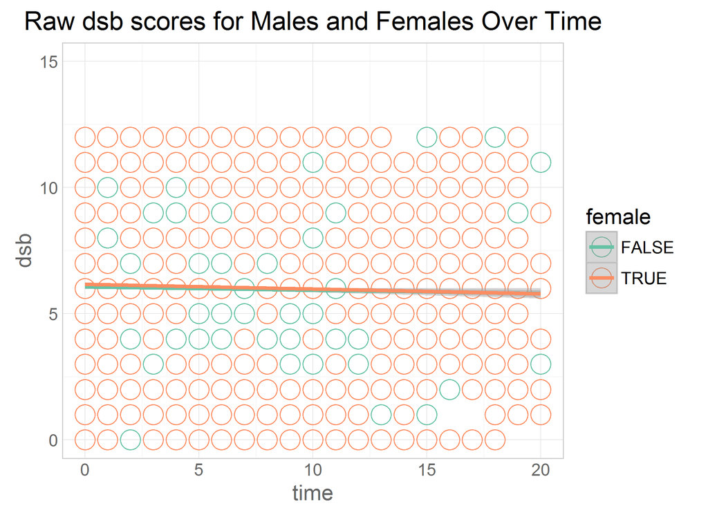

## MMSE over time

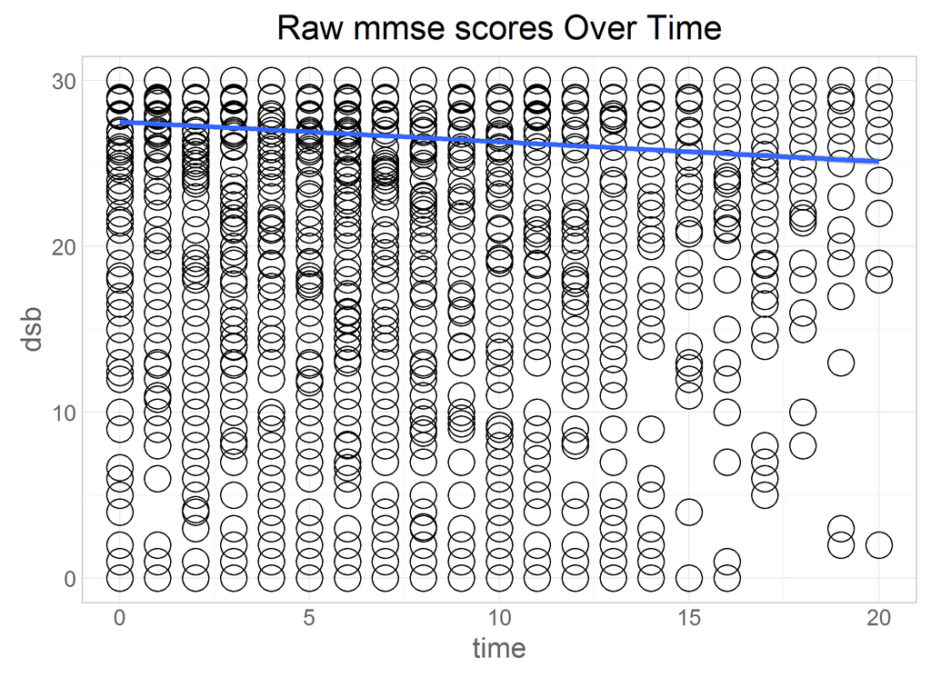

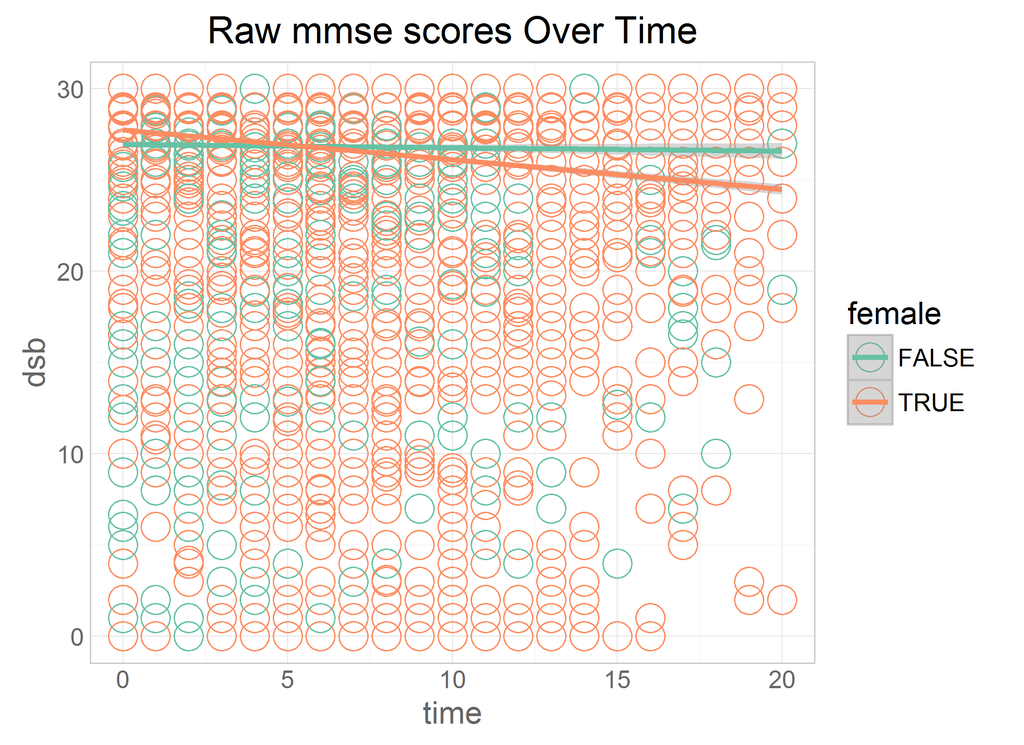

## PA over time

male walk more than the population average

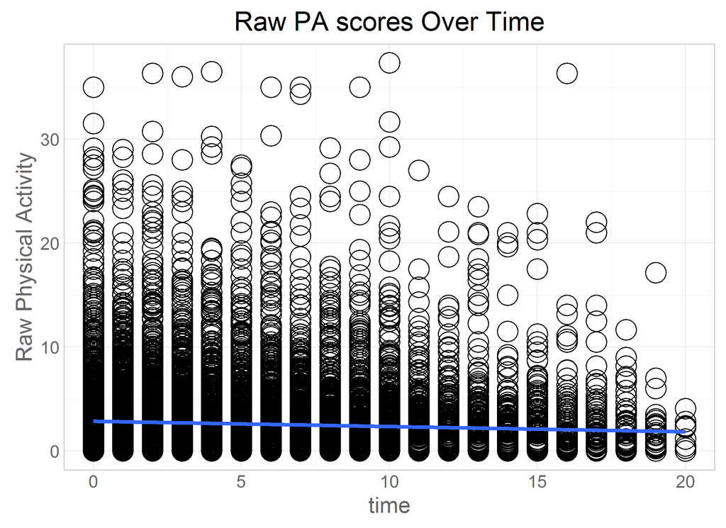

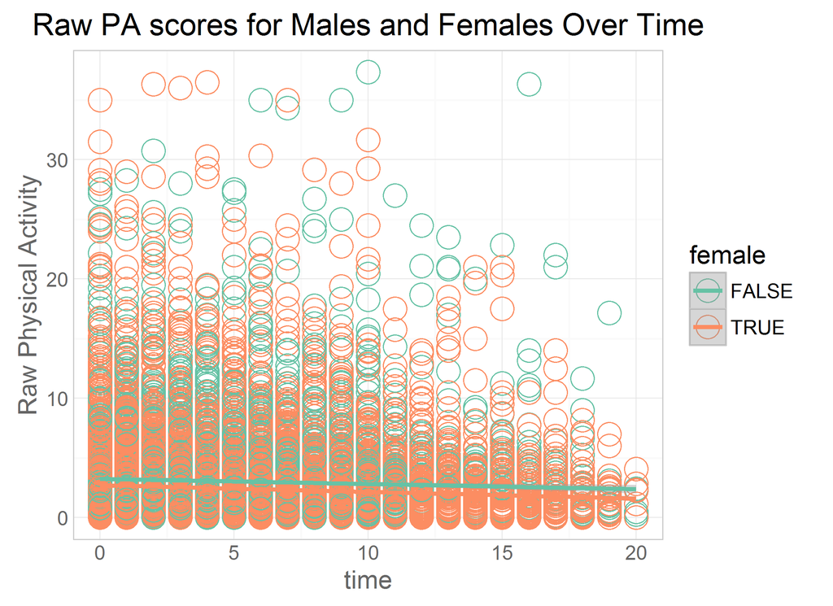

## Between person effects

male walk more than the population average - but there are some males who are reporting really high PA across time, this could be pulling their average up

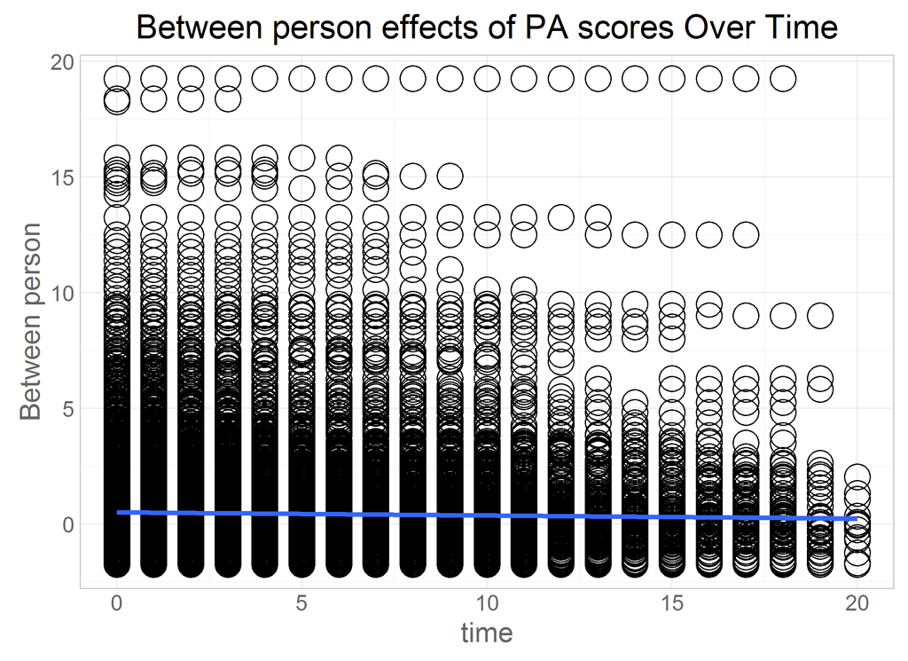

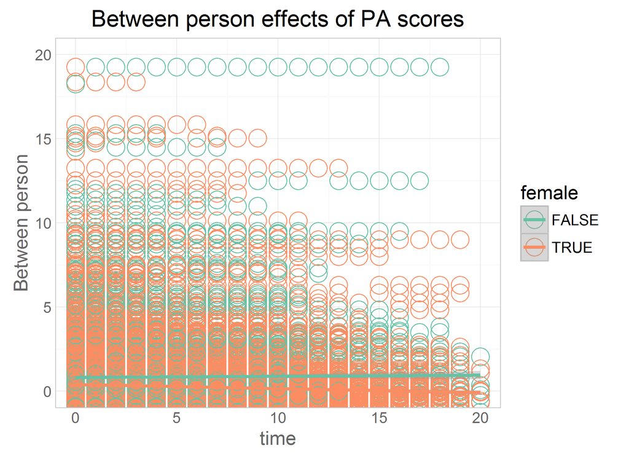